# A pipeline in R for the analysis of Infinium methylation array data

The code for the Welch test:

```r
t_test_all_rows <- function(x) {
  t_val <- t.test(x ~ targets$Group)
  return(t_val$p.value)
}

pval_raw_t <- apply(beta_norm, 1, t_test_all_rows)
summary(pval_raw_t)
```

```
##    Min. 1st Qu.  Median    Mean 3rd Qu.    Max.
##  0.0000  0.1994  0.4399  0.4593  0.7107  1.0000
```

```r
length(pval_raw_t)
```

```
## [1] 485512
```

The code for obtaining the joined dataset and for multiple testing correction:

```r
beta_rawp_df_t <- data.frame(beta_norm, pval_raw_t)
beta_rawp_df_sorted_t <-
  beta_rawp_df_t[order(beta_rawp_df_t$pval_raw_t), ]
summary(beta_rawp_df_sorted_t)
```

```
##  X5775278051_R01C01 X5775278051_R04C02 X5775278078_R02C01 X5775278078_R05C01
##  Min.   :0.00000    Min.   :0.00000    Min.   :0.00000    Min.   :0.0000
##  1st Qu.:0.04591    1st Qu.:0.05082    1st Qu.:0.04892    1st Qu.:0.0514
##  Median :0.66239    Median :0.66205    Median :0.65265    Median :0.6483
##  Mean   :0.50624    Mean   :0.50733    Mean   :0.50645    Mean   :0.5066
##  3rd Qu.:0.88802    3rd Qu.:0.88803    3rd Qu.:0.88615    3rd Qu.:0.8874
##  Max.   :0.99361    Max.   :0.99456    Max.   :0.99461    Max.   :0.9945
##  X5775278078_R05C02 X5930514034_R01C02 X5930514035_R04C02 X5930514035_R06C02
##  Min.   :0.00000    Min.   :0.00000    Min.   :0.0000     Min.   :0.00000
##  1st Qu.:0.05529    1st Qu.:0.04776    1st Qu.:0.0534     1st Qu.:0.04739
##  Median :0.65274    Median :0.64770    Median :0.6582     Median :0.64441
##  Mean   :0.50920    Mean   :0.50574    Mean   :0.5089     Mean   :0.50431
##  3rd Qu.:0.88597    3rd Qu.:0.88921    3rd Qu.:0.8882     3rd Qu.:0.88865
##  Max.   :0.99310    Max.   :0.99389    Max.   :0.9948     Max.   :0.99429
##    pval_raw_t
##  Min.   :0.0000
##  1st Qu.:0.1994
##  Median :0.4399
##  Mean   :0.4593
##  3rd Qu.:0.7107
##  Max.   :1.0000
```

```r
raw_p_sorted_t <- beta_rawp_df_sorted_t[, 9]
summary(raw_p_sorted_t)
```

```
##    Min. 1st Qu.  Median    Mean 3rd Qu.    Max.
##  0.0000  0.1994  0.4399  0.4593  0.7107  1.0000
```

```r
BH_p_t <- p.adjust(raw_p_sorted_t, "BH")
summary(BH_p)
```

[output not shown]

```r
Bonf_p_t <- p.adjust(raw_p_sorted_t, "bonferroni")
summary(Bonf_p_t)
```

```
##    Min. 1st Qu.  Median    Mean 3rd Qu.    Max.
##  0.0173  1.0000  1.0000  1.0000  1.0000  1.0000
```

```r
complete_beta_p_df_t <-
  data.frame(beta_rawp_df_sorted_t, BH_p_t, Bonf_p_t)
```

The code for the volcano plot:

```r
beta_norm_sorted_t <- complete_beta_p_df_t[, 1:8]
beta_norm_sorted_DS_t <- beta_norm_sorted_t[, groups == "DS"]
beta_norm_sorted_WT_t <- beta_norm_sorted_t[, groups == "WT"]
mean_beta_DS_t <- apply(beta_norm_sorted_DS_t, 1, mean)
mean_beta_WT_t <- apply(beta_norm_sorted_WT_t, 1, mean)
delta_t <- mean_beta_DS_t - mean_beta_WT_t
summary(delta_t)
```

```
##       Min.    1st Qu.     Median       Mean    3rd Qu.       Max.
## -0.5763406 -0.0061096 -0.0001211  0.0003977  0.0059492  0.6507866
```

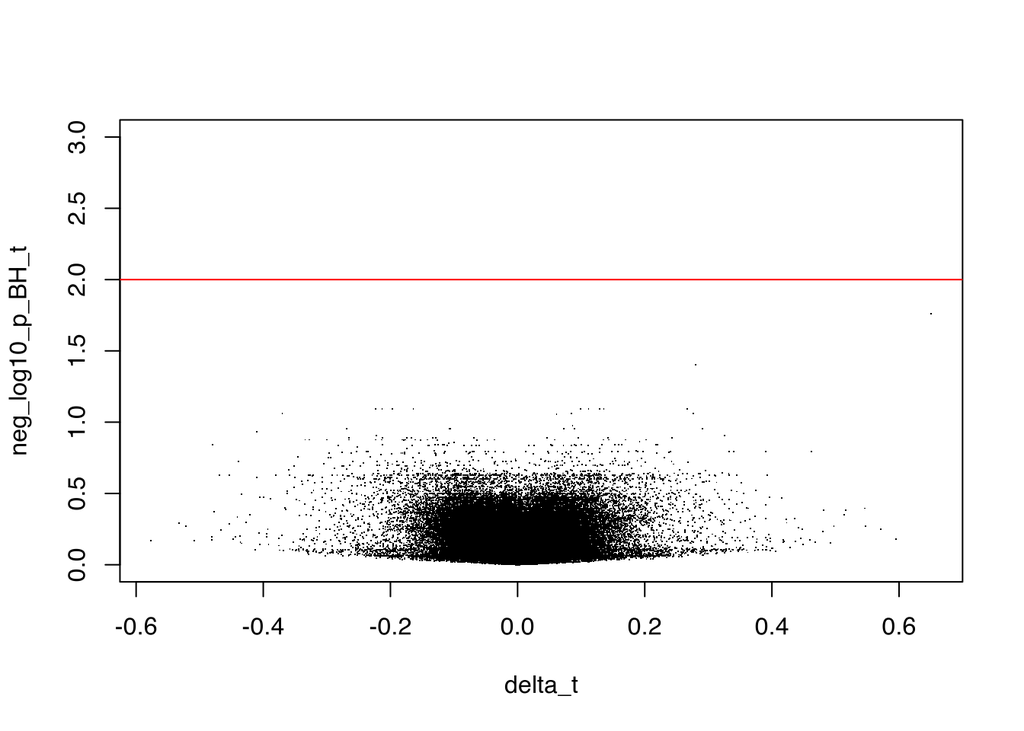

```r
neg_log10_p_BH_t <- -log10(complete_beta_p_df_t[, 10])
plot(delta_t,
     neg_log10_p_BH_t,
     ylim = c(0, 3),
     pch = '.')
abline(a = -log10(0.01),
       b = 0,
       col = "red")
```

The code for the Manhattan plot:

```r
df_manhattan_t <-
  data.frame(rownames(complete_beta_p_df_t), complete_beta_p_df_t)
colnames(df_manhattan_t)[1] <- 'Name'
annotation <- getAnnotation(RGSet)
colnames(annotation)
```

```
##  [1] "chr"                      "pos"
##  [3] "strand"                   "Name"
##  [5] "AddressA"                 "AddressB"
##  [7] "ProbeSeqA"                "ProbeSeqB"
##  [9] "Type"                     "NextBase"
## [11] "Color"                    "Probe_rs"
## [13] "Probe_maf"                "CpG_rs"
## [15] "CpG_maf"                  "SBE_rs"
## [17] "SBE_maf"                  "Islands_Name"
## [19] "Relation_to_Island"       "Forward_Sequence"
## [21] "SourceSeq"                "Random_Loci"
## [23] "Methyl27_Loci"            "UCSC_RefGene_Name"
## [25] "UCSC_RefGene_Accession"   "UCSC_RefGene_Group"
## [27] "Phantom"                  "DMR"
## [29] "Enhancer"                 "HMM_Island"
## [31] "Regulatory_Feature_Name"  "Regulatory_Feature_Group"
## [33] "DHS"
```

```r
complete_df_annotated_t <-
  merge(df_manhattan_t, annotation, by = "Name")
colnames(complete_df_annotated_t)
```

```
##  [1] "Name"                     "X5775278051_R01C01"
##  [3] "X5775278051_R04C02"       "X5775278078_R02C01"
##  [5] "X5775278078_R05C01"       "X5775278078_R05C02"
##  [7] "X5930514034_R01C02"       "X5930514035_R04C02"
##  [9] "X5930514035_R06C02"       "pval_raw_t"
## [11] "BH_p_t"                   "Bonf_p_t"
## [13] "chr"                      "pos"
## [15] "strand"                   "AddressA"
## [17] "AddressB"                 "ProbeSeqA"
## [19] "ProbeSeqB"                "Type"
## [21] "NextBase"                 "Color"
## [23] "Probe_rs"                 "Probe_maf"
## [25] "CpG_rs"                   "CpG_maf"
## [27] "SBE_rs"                   "SBE_maf"
## [29] "Islands_Name"             "Relation_to_Island"
## [31] "Forward_Sequence"         "SourceSeq"
## [33] "Random_Loci"              "Methyl27_Loci"
## [35] "UCSC_RefGene_Name"        "UCSC_RefGene_Accession"
## [37] "UCSC_RefGene_Group"       "Phantom"
## [39] "DMR"                      "Enhancer"
## [41] "HMM_Island"               "Regulatory_Feature_Name"
## [43] "Regulatory_Feature_Group" "DHS"
```

```r
chr_vect_t <-
  factor(
    complete_df_annotated_t$chr,
    levels = c(
      "chr1",
      "chr2",
      "chr3",
      "chr4",
      "chr5",
      "chr6",
      "chr7",
      "chr8",
      "chr9",
      "chr10",
      "chr11",
      "chr12",
      "chr13",
      "chr14",
      "chr15",
      "chr16",
      "chr17",
      "chr18",
      "chr19",
      "chr20",
      "chr21",
      "chr22",
      "chrX",
      "chrY"
    )
  )
input_manhattan_t <-
  data.frame(chr_vect_t,
             complete_df_annotated_t$pos,
             complete_df_annotated_t$BH_p_t)
colnames(input_manhattan_t) <- c('chr', 'pos', 'BH_pval')
str(input_manhattan_t)
```

```
## 'data.frame':    485512 obs. of  3 variables:
##  $ chr    : Factor w/ 24 levels "chr1","chr2",..: 16 3 3 1 8 14 16 8 1 15 ...
##  $ pos    : int  53468112 37459206 171916037 91194674 42263294 69341139 28890100 41167802 230560793 23034447 ...
##  $ BH_pval: num  0.779 0.829 0.861 0.871 0.716 ...
```

```r
palette_t <- rainbow(24)
mhtplot(
  input_manhattan_t,
  control = mht.control(colors = palette_t),
  ylim = c(0, 3),
  pch = 16
)
```

```
## Plotting points  1 - 46857
## Plotting points  46858 - 81667
## Plotting points  81668 - 106826
## Plotting points  106827 - 127290
## Plotting points  127291 - 151617
## Plotting points  151618 - 188228
## Plotting points  188229 - 218245
## Plotting points  218246 - 239195
## Plotting points  239196 - 249056
## Plotting points  249057 - 273444
## Plotting points  273445 - 302238
## Plotting points  302239 - 326777
## Plotting points  326778 - 339062
## Plotting points  339063 - 354140
## Plotting points  354141 - 369399
## Plotting points  369400 - 391368
## Plotting points  391369 - 419247
## Plotting points  419248 - 425169
## Plotting points  425170 - 450690
## Plotting points  450691 - 461069
## Plotting points  461070 - 465312
## Plotting points  465313 - 473864
## Plotting points  473865 - 485096
## Plotting points  485097 - 485512
```

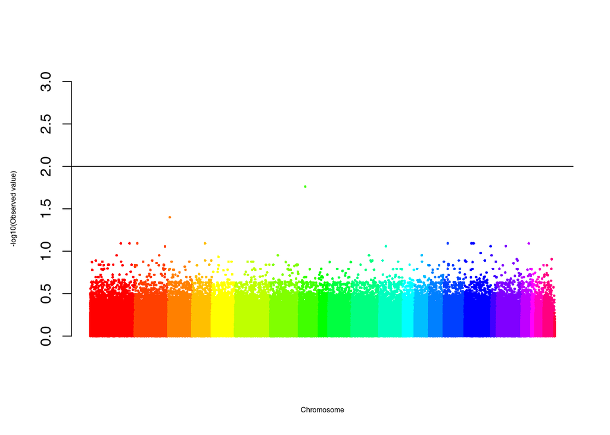

```r
axis(2, cex = 0.5)
abline(a = -log10(0.01), b = 0)
```

Now the volcano and Manhattan plots look more familiar. Therefore, I conclude that the peculiar appearance of the volcano and Manhattan plots is due to the use of a non-parametric test, which does not have enough statistical power to detect differentially methylated probes in this dataset.

# Optional task

> As `DS` is caused by the trisomy of chromosome 21, try also to plot the density of the methylation values of the probes mapping on chromosome 21.

> Do you see a very clear difference between the samples?

> How many differentially methylated probes do you find on chromosome 21?

First I extract the rows relative to probes belonging to chromosome 21 from the complete dataset prepared in step 12 and I subset it according to the group of the samples.

```r
chr21_complete <-
  complete_df_annotated[complete_df_annotated$chr == 'chr21', ]
chr21_beta <- chr21_complete[, 2:9]
chr21_beta_WT <- chr21_beta[, groups == 'WT']
chr21_beta_DS <- chr21_beta[, groups == 'DS']
dim(chr21_beta_DS)
```

```
## [1] 4243    4
```

```r
dim(chr21_beta_WT)
```

```
## [1] 4243    4
```

Now I calculate the mean beta values of each probe in each of the sample groups, and the density of mean beta values.

```r
chr21_beta_DS_mean <- apply(chr21_beta_DS, MARGIN = 1, mean, na.rm = T)
chr21_beta_WT_mean <- apply(chr21_beta_WT, MARGIN = 1, mean, na.rm = T)
d_mean_chr21_beta_DS <- density(chr21_beta_DS_mean)
d_mean_chr21_beta_WT <- density(chr21_beta_WT_mean)
```

Finally, I plot the densities of mean beta values differentiated by sample group, only for probes on chromosome 21.

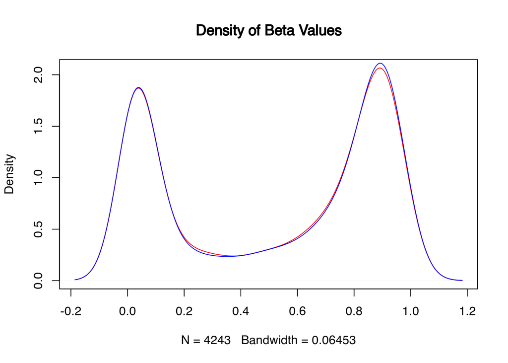

```r
plot(d_mean_chr21_beta_DS, main = "Density of Beta Values", col = "red")
lines(d_mean_chr21_beta_WT, main = "Density of Beta Values", col = "blue")
```

The red line refers to the `DS` group, while the blue line refers to the `WT` group. I observe that there are no obviuos differences among `DS` and `WT` samples regarding the distribution of mean beta values for probes on chromosome 21. Only the methylated peak of beta values seems slightly more pronounced in the `WT` group.

Now I want to evaluate how many probes are differentially methylated on chromosome 21. I will just extract this information from the complete data frame obtained in the previous steps. I will use raw p-values here.

```r
diff_met_chr21 <- chr21_complete[chr21_complete$pval_raw <= 0.01, ]
dim(diff_met_chr21)
```

```
## [1]  0 44
```